# Comprehensive Knowledge of C++(V20.09)

autor:ichiroprogrammer

# 用語解説

この章では、このドキュメントで使用する用語の解説をする。

**この章の構成**

組み込み型とインスタンス  
基本型  
組み込み型  
算術型  
汎整数型  
整数型  
算術変換  
汎整数型昇格  
汎整数型拡張  
浮動小数点型昇格  
デフォルト引数昇格  
縮小型変換  
浮動小数点型  
浮動小数点型のダイナミックレンジ  
浮動小数点の誤差  
イプシロン  
浮動小数点の演算エラー

enum  
enum class  
スコープドenum  
underlying type  
std::byte  
using enum

型とインスタンス  
特殊メンバ関数  
ゼロの原則(Rule of Zero)  
五の原則(Rule of Five)

トリビアル型  
トリビアルに破壊可能な型  
標準レイアウト型  
集成体  
POD  
不完全型  
完全型  
ポリモーフィックなクラス  
オーバーライドとオーバーロードの違い  
RTTI  
dynamic_cast  
typeid  
std::type_info

Run-time Type Information  
インターフェースクラス  
constインスタンス

constexpr  
constexpr定数  
constexpr関数  
コア定数式  
リテラル型  
constexprインスタンス  
consteval  
constexprラムダ

オブジェクトと生成  
リスト初期化  
一様初期化  
初期化子リストコンストラクタ  
継承コンストラクタ  
委譲コンストラクタ  
非静的なメンバ変数の初期化  
NSDMI  
初期化子リストでの初期化  
コンストラクタ内での非静的なメンバ変数の初期値の代入

オブジェクトの所有権  
オブジェクトの排他所有  
オブジェクトの共有所有  
オブジェクトの循環所有  
std::weak_ptr

オブジェクトのライフタイム  
オブジェクトのコピー  
シャローコピー  
ディープコピー  
スライシング

リテラル  
生文字列リテラル  
2進数リテラル  
数値リテラル  
ワイド文字列  
16進浮動小数点数リテラル  
ユーザー定義リテラル  
ユーザ定義リテラル演算子  
std::string型リテラル  
std::chronoのリテラル  
std::complexリテラル

==演算子  
メンバ==演算子  
非メンバ==演算子

比較演算子  
std::rel_ops  
std::tuppleを使用した比較演算子の実装方法  
<=>演算子  
三方比較演算子  
spaceship operator

構文  
属性構文  
関数tryブロック  
範囲for文  
構造化束縛  
初期化付きif/switch文  
初期化付きfor文(従来のfor文)  
初期化付きwhile文(従来のwhile文)  
初期化付きif文  
初期化付きswitch文

言語機能  
コルーチン  
co_await  
co_return  
co_yield

モジュール  
ラムダ式  
クロージャ  
クロージャ型  
一時的ラムダ  
transient lambda

指示付き初期化

プログラミング概念と標準ライブラリ  
スマートポインタ  
コンテナ  
シーケンスコンテナ(Sequence Containers)  
連想コンテナ(Associative Containers)  
無順序連想コンテナ(Unordered Associative Containers)  
コンテナアダプタ(Container Adapters)  
特殊なコンテナ

std::optional  
戻り値の無効表現  
オブジェクトの遅延初期化

std::variant

name lookupと名前空間  
ルックアップ  
name lookup  
two phase name lookup  
実引数依存探索  
ADL  
関連名前空間  
修飾付き関数呼び出し  
hidden-friend関数  
name-hiding  
ダイヤモンド継承  
仮想継承  
仮想基底  
ドミナンス  
ダイヤモンド継承を含まない場合  
ダイヤモンド継承かつそれが仮想継承でない場合  
ダイヤモンド継承かつそれが仮想継承である場合

using宣言  
usingディレクティブ

template強化機能  
SFINAE  
コンセプト  
畳み込み式  
ジェネリックラムダ  
クラステンプレートのテンプレート引数の型推論  
テンプレートの型推論ガイド  
CTAD(Class Template Argument Deduction)  
変数テンプレート  
エイリアステンプレート  
constexpr if文  
autoパラメータによる関数テンプレートの簡易定義

型推論  
AAAスタイル  
decltype  
decltype(auto)  
CTAD（Class Template Argument Deduction）  
戻り値型を後置する関数宣言  
関数の戻り値型auto  
後置戻り値型auto

explicit  
暗黙の型変換  
暗黙の型変換抑止  
explicit type operator()  
explicit(COND)

expressionと値カテゴリ  
expression  
lvalue  
rvalue  
xvalue  
prvalue  
glvalue

decltypeとexpression

リファレンス  
lvalueリファレンス  
rvalueリファレンス  
lvalueからの代入  
rvalueからの代入  
std::move(lvalue)からの代入

forwardingリファレンス  
ユニバーサルリファレンス  
perfect forwarding  
リファレンスcollapsing  
danglingリファレンス  
danglingポインタ

リファレンス修飾  
rvalue修飾  
lvalue修飾

エクセプション安全性の保証  
no-fail保証  
強い安全性の保証  
基本的な安全性の保証  
noexcept  
exception-unfriendly

シンタックス、セマンティクス  
等価性のセマンティクス  
copyセマンティクス  
moveセマンティクス  
MoveAssignable要件  
CopyAssignable要件

C++その他  
型特性キーワード  
alignof  
alignas  
addressof

演算子のオペランドの評価順位  
実引数/仮引数  
単純代入  
ill-formed  
well-formed  
未定義動作  
未規定動作  
未定義動作と未規定動作  
被修飾型  
one-definition rule  
ODR  
RVO(Return Value Optimization)  
SSO(Small String Optimization)  
heap allocation elision  
Most Vexing Parse  
トライグラフ

C++コンパイラ  
g++  
clang++

ソフトウェア一般  
ハンドル  
フリースタンディング環境  
サイクロマティック複雑度  
凝集度  
凝集度の欠如  
LCOMの評価基準

Spurious Wakeup  
副作用  
is-a  
has-a  
is-implemented-in-terms-of  
public継承によるis-implemented-in-terms-of  
private継承によるis-implemented-in-terms-of  
コンポジションによる(has-a)is-implemented-in-terms-of

非ソフトウェア用語  
割れ窓理論  
車輪の再発明

このドキュメントの構成に戻る。

## 組み込み型とインスタンス

### 基本型

基本型(fundamental types)は、C++の標準で定義されている型で、 特別なキーワードを使用して直接宣言できる型の総称である。 組み込み型とも呼ばれることもある。

基本型は以下のに示した型によって構成される。

- 算術型
- 汎整数型
- 浮動小数点型
- void
- 上記した型のポインタ型

注:  
リファレンスは基本型に含まれない。

### 組み込み型

組み込み型(built-in types)は基本型(fundamental types)の別称。

### 算術型

算術型とは下記の型の総称である。

- 汎整数型(bool, char, int, unsigned int, long long等)
- 浮動小数点型(float、double、long double)

算術型のサイズは下記のように規定されている。

- 1 == sizeof(bool) == sizeof(char)
- sizeof(char) <= sizeof(short) <= sizeof(int) <= sizeof(long) <= sizeof(long long)
- 4 <= sizeof(long)
- 8 <= sizeof(long long)
- 4 == sizeof(float)
- 8 == sizeof(double) <= sizeof(long double)

### 汎整数型

汎整数型とは下記の型の総称である。

- 論理型(bool)
- 文字型(char、wchar_t等)
- 整数型(int、unsigned int、long等)

### 整数型

整数型とは下記の型の総称である。

- signed char
- unsigned char
- short
- unsigned short
- int
- unsigned int
- long
- unsigned long
- long long
- unsigned long long

### 算術変換

C++における算術変換とは、算術演算の1つのオペランドが他のオペランドと同じ型でない場合、 1つのオペランドを他のオペランドと同じ型に変換するプロセスのことを指す。

算術変換は、汎整数型昇格と通常算術変換に分けられる。

```cpp
    //  example/term_explanation/integral_promotion_ut.cpp 11

    bool           bval{};
    char           cval{};
    short          sval{};
    unsigned short usval{};
    int            ival{};
    unsigned int   uival{};
    long           lval{};
    unsigned long  ulval{};
    float          fval{};
    double         dval{};

    auto ret_0 = 3.14159 + 'a';  // 'a'は汎整数拡張でintになった後、さらに通常算術変換でdoubleに
    static_assert(std::is_same<decltype(ret_0), double>::value, "");

    auto ret_1 = dval + ival;  // ivalは通常算術変換でdoubleに
    static_assert(std::is_same<decltype(ret_1), double>::value, "");

    auto ret_2 = dval + fval;  // fvalは通常算術変換でdoubleに
    static_assert(std::is_same<decltype(ret_2), double>::value, "");

    auto ret_3 = ival = dval;  // dvalは通常算術変換でintに
    static_assert(std::is_same<decltype(ret_3), int>::value, "");

    bval = dval;  // dvalは通常算術変換でboolに
    ASSERT_FALSE(bval);

    auto ret_4 = cval + fval;  // cvalは汎整数拡張でintになった後、さらに通常算術変換でfloatに
    static_assert(std::is_same<decltype(ret_4), float>::value, "");

    auto ret_5 = sval + cval;  // svalとcvalは汎整数拡張でintに
    static_assert(std::is_same<decltype(ret_5), int>::value, "");

    auto ret_6 = cval + lval;  // cvalはは汎整数拡張でintになった後、通常算術変換でlongに
    static_assert(std::is_same<decltype(ret_6), long>::value, "");

    auto ret_7 = ival + ulval;  // ivalは通常算術変換でunsigned longに
    static_assert(std::is_same<decltype(ret_7), unsigned long>::value, "");

    auto ret_8 = usval + ival;  // usvalは汎整数拡張でintに
                                // ただし、この変換はunsigned shortとintのサイズに依存する
    static_assert(std::is_same<decltype(ret_8), int>::value, "");

    auto ret_9 = uival + lval;  // uivalは通常算術変換でlongに
                                // ただし、この変換はunsigned intとlongのサイズに依存する
    static_assert(std::is_same<decltype(ret_9), long>::value, "");
```

一様初期化を使用することで、 変数定義時の算術変換による意図しない値の変換(縮小型変換)を防ぐことができる。

```cpp
    //  example/term_explanation/integral_promotion_ut.cpp 62

    int i{-1};
    // int8_t i8 {i};  縮小型変換によりコンパイル不可
    int8_t i8 = i;  // intからint8_tへの型変換
    // これには問題ないが

    ASSERT_EQ(-1, i8);

    // uint8_t ui8 {i};  縮小型変換によりコンパイル不可
    uint8_t ui8 = i;  // intからuint8_tへの型変換
    // おそらく意図通りではない

    ASSERT_EQ(255, ui8);
```

以下に示すように、算術変換の結果は直感に反することがあるため、注意が必要である。

```cpp
    //  example/term_explanation/integral_promotion_ut.cpp 81

    int          i{-1};
    unsigned int ui{1};

    // ASSERT_TRUE(i < ui);
    ASSERT_TRUE(i > ui);  // 算術変換の影響で、-1 < 1が成立しない

    signed short   s{-1};
    unsigned short us{1};

    ASSERT_TRUE(s < us);  // 汎整数拡張により、-1 < 1が成立
```

### 汎整数型昇格

bool、char、signed char、unsigned char、short、unsigned short型の変数が、 算術のオペランドとして使用される場合、

- その変数の型の取り得る値全てがintで表現できるのならば、int型に変換される。
- そうでなければ、その変数はunsigned int型に変換される。

この変換を汎整数型昇格(integral promotion)と呼ぶ。

従って、sizof(short) < sizeof(int)である処理系では、 bool、char、signed char、unsigned char、short、unsigned short型の変数は、 下記のようにintに変換される。

```cpp
    //  example/term_explanation/integral_promotion_ut.cpp 100

    bool bval;
    static_assert(std::is_same<int, decltype(bval + bval)>::value, "");

    char cval;
    static_assert(std::is_same<int, decltype(cval + cval)>::value, "");

    unsigned char ucval = 128;
    static_assert(std::is_same<int, decltype(ucval + ucval)>::value, "");
    ASSERT_EQ(256, ucval + ucval);  // 汎整数拡張により256になる

    static_assert(std::is_same<int, decltype(cval + ucval)>::value, "");

    short sval;
    static_assert(std::is_same<int, decltype(sval + sval)>::value, "");

    unsigned short usval;
    static_assert(std::is_same<int, decltype(usval + usval)>::value, "");

    static_assert(std::is_same<int, decltype(sval + usval)>::value, "");
```

### 汎整数型拡張

汎整数型拡張とは汎整数型昇格と同じ概念を指す。

### 浮動小数点型昇格

浮動小数点型昇格とは、float型とdouble型の演算で、 float型オブジェクトがdoulbe型に変換されることを指す。

```cpp
    //  example/term_explanation/integral_promotion_ut.cpp 126

    double d = 0.05;  // 0.05は循環少数
    float  f = 0.05f;

    bool b1 = d == f;  // fはdoubleに昇格
    ASSERT_FALSE(b1);  // 0.05は循環少数であるため、0.5と0.5fは異なる。

    bool b2 = std::abs(d - f) <= std::numeric_limits<decltype(d - f)>::epsilon();
    ASSERT_FALSE(b2);  // dとfの差はdoubleのイプシロンには収まらない。
```

### デフォルト引数昇格

デフォルト引数昇格(Default Argument Promotions)とは、可変長引数`(...)`や、 プロトタイプを持たない関数に算術型引数を渡す際に適用される昇格ルールの総称である。

デフォルト引数昇格には以下が含まれる。

- 汎整数型昇格
- 浮動小数点型昇格

### 縮小型変換

縮小型変換(Narrowing Conversion) とは、あるデータ型から別のデータ型に変換する際に、 変換先の型が元の型の表現範囲を完全にカバーしていない場合に発生する変換を指す。 主に整数型や浮動小数点型などの値を小さな範囲の型に変換する際に起こる。

```cpp
    //  example/term_explanation/etc_ut.cpp 43

    int32_t large  = 300;
    int8_t  small  = large;  // 縮小型変換
    bool    b      = large;
    double  d      = large;  // 単単なる型変換(縮小ではない)
    int32_t large2 = d;      // 縮小型変換

    // large = int32_t{d};   縮小型変換回避のためリスト初期化の使用。コンパイルエラー
```

リスト初期化を使うことで、このような変換によるバグの発生を防ぐことができる。

### 浮動小数点型

浮動小数点型は以下の型の総称である。

- `float`
- `double`
- `long double`

浮動小数点の仕様は、IEEE 754標準に準拠している。 この標準は、浮動小数点演算の表現方法、精度、丸め方法、および例外処理を規定しており、 広く使用されている。

#### 浮動小数点型のダイナミックレンジ

| 型 | 正の最小値 | 正の最大値 |
| --- | --- | --- |
| `float` | 1.175494351 e-38 | 3.402823466 e+38 |
| `double` | 2.2250738585072014 e-308 | 1.7976931348623158 e+308 |
| `long double` | 3.36210314311209350626 e-4932 | 1.18973149535723176502 e+4932 |
| `int32_t` | -2,147,483,648 | 2,147,483,647 |
| `int64_t` | -9,223,372,036,854,775,808 | 9,223,372,036,854,775,807 |

ここで`long double`の最小値と最大値は、システムやコンパイラに依存して異なる場合がある点に留意する。

#### 浮動小数点の誤差

浮動小数点変数の10進数の表現が2進数では循環小数となる場合があり、 正確に表現できないことがある。これにより、計算結果がわずかに異なる値を返す場合がある。 浮動小数点誤差は、特に計算の繰り返しや桁数の多い計算で顕著になる。

以下のコードにより誤差が容易に発生することを示す。

```cpp
    //  example/term_explanation/float_ut.cpp 12

    // 下記の0.01は2進数では循環小数となるため、実数の0.01とは異なる。
    constexpr auto a = 0.01F;  // 0.0000001010001111...
    constexpr auto b = 0.04F;  // 0.0000101000111101...

    //  ASSERT_EQ(0.05F, a + b);  // NG  a + b == 0.05Fは一般には成立しない。
    ASSERT_NE(0.05F, a + b);
```

#### イプシロン

イプシロン(epsilon)とは、ある浮動小数点数に対して「1」を加えた時に、 異なる値として識別できる最小の差分を指す。 つまり、イプシロンは浮動小数点数の精度を示す尺度である。

任意の浮動小数点変数a, bがあり、`|a - b| <= epsilon`であった場合、 浮動小数点の仕組みではa、bの差が無いものと考えて、aとbが同値であると考えることが一般的である。

イプシロンを使用した浮動小数点変数の同値判定のコード例を以下に示す。

```cpp
    //  example/term_explanation/float_ut.cpp 24

    // 下記の0.01は2進数では循環小数となるため、実数の0.01とは異なる。
    constexpr auto a = 0.01F;  // 0.0000001010001111...
    constexpr auto b = 0.04F;  // 0.0000101000111101...

    bool is_equal = 0.05F == (a + b);
    ASSERT_FALSE(is_equal);  // is_equalはtrueにはならない

    bool is_nearly_equal = std::abs(0.05F - (a + b)) <= std::numeric_limits<float>::epsilon();
    ASSERT_TRUE(is_nearly_equal);  // 浮動小数点の同値はこのように判定する
```

#### 浮動小数点の演算エラー

浮動小数点の演算は以下のようなエラーを生じることがある。

[output not shown]

浮動小数点の演算エラーの検出コード例を以下に示す。

```cpp
    //  example/term_explanation/float_ut.cpp 43

    std::feclearexcept(FE_ALL_EXCEPT);  // エラーをクリア

    div(1.0F, 0.0F);  // 関数の中で0除算するが、終了シグナルは発生しない
    ASSERT_TRUE(std::fetestexcept(FE_ALL_EXCEPT) & FE_DIVBYZERO);  // 0除算

    std::feclearexcept(FE_ALL_EXCEPT);  // エラーをクリア

    div(std::numeric_limits<double>::max(), 1);

    auto const excepts = std::fetestexcept(FE_ALL_EXCEPT);

    ASSERT_FALSE(excepts & FE_DIVBYZERO);  // 0除算
    ASSERT_TRUE(excepts & FE_INEXACT);     // 演算が不正確
    ASSERT_FALSE(excepts & FE_INVALID);    // 不正な操作
    ASSERT_TRUE(excepts & FE_OVERFLOW);    // 演算がオーバーフローを起こした
    ASSERT_FALSE(excepts & FE_UNDERFLOW);  // 演算がアンダーフローを起こした

    std::feclearexcept(FE_ALL_EXCEPT);  // エラーをクリア

    auto const a = 1.0F / global_zero;  // global_zero == 0
    ASSERT_TRUE(std::isinf(a));

    auto const b = std::sqrt(-1);
    auto const c = std::sqrt(-1);
    ASSERT_TRUE(std::isnan(b));
    ASSERT_FALSE(b == c);  // NaN == NaNは常にfalse
```

なお、上記のコードで使用した`std::fetestexcept`は一般にスレッドセーフである。 `std::fetestexcept`がスレッドセーフでない処理系では、浮動小数演算エラーの検出は、 実質的には不可能になってしまうため、 浮動小数演算を複数コンテキストで行うソフトウェアの開発する場合、 処理系の選択に注意が必要である。

## enum

C++03までのenumは定数を分かりやすい名前で定義するための記法である。 このドキュメントでは、スコープドenumに対して、C++03までのenumを非スコープドenum、 通常のenum、あるいは単にenumと呼ぶことがある。 C++03までのenumには、以下のような問題があった。

- スコープの制限: 名前付きスコープ内に定義するためには、クラスのメンバとして定義しなければならない。
- 型安全性: enumの値は整数型と暗黙の変換が行われてしまう。
- 名前空間の汚染: グローバルスコープに定義されたenumは、名前空間を汚染する。

```cpp
    //  example/term_explanation/enum_ut.cpp 14

    enum DayOfWeek { Sunday, Monday, Tuesday, Wednesday, Thursday, Friday, Saturday };

    ASSERT_TRUE(1 == Monday);  // intへの暗黙の変換

    enum Color { Red, Green, Blue };

    ASSERT_TRUE(Green == Monday);  // 別のenumが比較できてしまう
```

### enum class

enum classは通常のenumの問題を解決するためにC++11から導入された。

```cpp
    //  example/term_explanation/enum_ut.cpp 29

    enum class DayOfWeek { Sunday, Monday, Tuesday, Wednesday, Thursday, Friday, Saturday };

    // ASSERT_TRUE(1 == Monday);  // intへの暗黙の変換できないため、コンパイルエラー
    ASSERT_TRUE(1 == static_cast<int>(DayOfWeek::Monday));

    enum class Color { Red, Green, Blue };

    // ASSERT_TRUE(Green == Monday);  // 別のenumが比較できないため、コンパイルエラー
    ASSERT_TRUE(static_cast<DayOfWeek>(Color::Green) == DayOfWeek::Monday);
```

```cpp
    //  example/term_explanation/enum_ut.cpp 41

    // DayOfWeek d0 {0}; intからの暗黙の型変換は許可されないため、コンパイルエラー
    DayOfWeek d0{static_cast<DayOfWeek>(0)};
    DayOfWeek d1{};  // デフォルト初期化
    ASSERT_EQ(d1, DayOfWeek::Sunday);

    DayOfWeek d2{DayOfWeek::Tuesday};  // 値あり初期化
```

### スコープドenum

enum classはスコープドenum(scoped enum)と呼ばれることがある。

### underlying type

underlying typeとは、enumやenum classの汎整数型を指定できるようにするために、 C++11で導入されたシンタックスである。enumのサイズをユーザが定義できるため、 特定のバイナリプロトコルとの互換性が必要な場合や、特定のハードウェアと連携する際に特に有効である。

```cpp
    //  example/term_explanation/enum_ut.cpp 54

    enum NormalEnum {  // underlying typeの指定しない従来のenum
    };

    enum NormalEnumUnderlyingType : int8_t {  // enum underlying typeがint8_tに指定された従来のenum
    };

    // enum class
    enum class EnumClass {  // underlying typeの指定しないenum class
    };

    enum class EnumClassUnderlyingType : int64_t {  // enum underlying typeがint64_tに指定されたenum
                                                    // class
    };

    static_assert(4 ==  sizeof(NormalEnum));  // 列挙子の値を表現するのに十分なサイズの整数型で処理系依存
    static_assert(4 ==  sizeof(EnumClass));   // 列挙子の値を表現するのに十分なサイズの整数型で処理系依存
    static_assert(sizeof(int8_t) == sizeof(NormalEnumUnderlyingType));
    static_assert(sizeof(int64_t) == sizeof(EnumClassUnderlyingType));
```

C++17までは、型安全の観点から、初期化においては、以下のコードコメントのような仕様であったが、 C++17から導入されたstd::byteの利便性のため、 underlying typeを指定したenumやenum class変数のunderlying typeインスタンスによる初期化が認められるようになった。

```cpp
    //  example/term_explanation/enum_ut.cpp 80

    enum class Color : int { Red, Green, Blue };

    // Color red{0}; C++14まではコンパイルエラー

    Color red{0};  // underlying typeの効果でC++17からコンパイルできる。

    long a{1};
    // Color green{a};  // 縮小型変換が発生するため、コンパイルエラー
```

上記コードにもあるが、underlying typeインスタンスによる初期化を行う場合は、 意図しない縮小型変換によるバグの発生を防ぐためにも、 一様初期化を使用するべきだろう。

一部の例外を除くとunderlying typeを指定しないenumやenum classはコンパイル時にサイズが確定できないため、 前方宣言できないが、underlying typeを指定したenum、enum classは前方宣言することができる。

```cpp
    //  example/term_explanation/enum_ut.cpp 97

    // in calender.h
    enum class DayOfWeek : int8_t;  // DayOfWeekの前方宣言

    bool calender(DayOfWeek);  // 前方宣言の効果でこのヘッダでの#include "day_of_week.h"が不要

    // in day_of_week.h
    enum class DayOfWeek : int8_t { Sunday, Monday, Tuesday, Wednesday, Thursday, Friday, Saturday };
```

### std::byte

C++17で導入されたstd::byte型は、バイト単位のデータ操作に使用され、 整数型としての意味を持たないため、型安全性を確保する。 uint8_t型と似ているが、uint8_t型の演算による汎整数型昇格を発生させないため、 可読性、保守性の向上が見込める。

```cpp
    //  example/term_explanation/enum_ut.cpp 113

    uint8_t u8_0     = 0x80;
    auto    result_0 = u8_0 << 1;  // 汎整数拡張のためresult_0の型はintになる

    static_assert(std::is_same_v<decltype(result_0), int>);
    ASSERT_EQ(0x100, result_0);  // これがわかりずらいバグにつながることがある

    auto u8_1     = std::byte{0x80};
    auto result_1 = u8_1 << 1;  // 汎整数拡張は発生せず、result_1の型はstd::byteになる

    static_assert(std::is_same_v<decltype(result_1), std::byte>);

    // 整数型を取り出すためには、暗黙の型変換ではなく、
    // 明示的なto_integerの呼び出しが必要になることもコードの安全性につながる
    ASSERT_EQ(0x00, std::to_integer<int>(result_1));  // 0x100はstd::byteでは0
```

### using enum

名前空間のように、

```cpp
    using enum EnumType;
```

もしくは

```cpp
    using EnumType::enumerator
```

とすることで、スコープによる修飾を省略するための記法である。

```cpp
    //  example/term_explanation/enum_ut.cpp 158

    enum class Color { Red, Green, Yellow };

    constexpr std::string_view to_str(Color color)
    {
    #if __cplusplus >= 202002L  // c++20
        using enum Color;       // 名前修飾の省略可能にする

        switch (color) {
        case Red:
            return "Red";
        case Green:
            return "Green";
        case Yellow:
            return "Yellow";
        }

    #else  // c++17
        switch (color) {
        case Color::Red:
            return "Red";
        case Color::Green:
            return "Green";
        case Color::Yellow:
            return "Yellow";
        }
    #endif
        assert(false);
        return "";
    }
```

```cpp
    //  example/term_explanation/enum_ut.cpp 194

    #if __cplusplus >= 202002L  // c++20
        using Color::Red;  // Redに関しては名前修飾なしで使用する

        ASSERT_EQ("Red", to_str(Red));
        ASSERT_EQ("Yellow", to_str(Color::Yellow));

    #else  // c++17
        ASSERT_EQ("Red", to_str(Color::Red));
        ASSERT_EQ("Yellow", to_str(Color::Yellow));
    #endif
```

```cpp
    //  example/term_explanation/enum_ut.cpp 213

    class Signal {
    public:
        enum class Color { Red, Green, Yellow };
        using enum Color;

        void Set(Color);

    private:
        // ...
    };
```

```cpp
    //  example/term_explanation/enum_ut.cpp 229

    Signal s{};

    s.Set(Signal::Color::Red);  // 名前修飾が長すぎる感じがする
    s.Set(Signal::Red);         // using enum colorがあるために、簡潔に書ける

    using Signal::Red;  // Redに関しては名前修飾なしで使用する
                        // この記述によりこの名前空間でのRed識別子が使えなくなる
    s.Set(Red);
```

この記法は、簡潔に記述できるものの、一方では過度な使用は、 C++03までのenumが持っていた問題を再発生させてしまうため、 ブロックスコープ以外での使用に関しては控え目に使用するべきだろう。

## 型とインスタンス

### 特殊メンバ関数

特殊メンバ関数とは下記の関数を指す。

- デフォルトコンストラクタ
- copyコンストラクタ
- copy代入演算子
- moveコンストラクタ
- move代入演算子
- デストラクタ

以下のメンバ関数は特殊関数ではないが、C++20から特殊関数と同様に`=default`とすることで自動生成される。

- ==演算子  
  クラス内のすべてのメンバが==をサポートしている場合、`= default`とすることで自動生成される。
- <=>演算子  
  すべてのメンバが<=>演算子での比較可能である場合、`= default`とすることで自動生成される。

ユーザがこれらを一切定義しない場合、または一部のみを定義する場合、 コンパイラは、下記のテーブル等で示すルールに従い、特殊関数メンバの宣言、定義の状態を定める。

左1列目がユーザによる各関数の宣言を表し、2列目以降はユーザ宣言の影響による各関数の宣言の状態を表す。  
下記表において、

- 「`= default`」とは、「コンパイラによってその関数が`= default`と宣言された」状態であることを表す。
- 「= default」とは、`= default`と同じであるが、バグが発生しやすいので推奨されない。
- 「宣言無し」とは、「コンパイラによってその関数が`= default`と宣言された状態ではない」ことを表す。
  - 「moveコンストラクタが`= default`と宣言された状態ではない」且つ 「copyコンストラクタが宣言されている」場合、 rvalueを使用したオブジェクトの初期化には、 moveコンストラクタの代わりにcopyコンストラクタが使われる。
  - 「move代入演算子が`= default`と宣言された状態ではない」且つ 「copy代入演算子が宣言されている」場合、 rvalueを使用したオブジェクトの代入には、 move代入演算子の代わりにcopy代入演算子が使われる。
- 「= delete」とは「コンパイラによってその関数が= deleteと宣言された」状態であることを表す。

| user-defined | default ctor | dtor | copy ctor | copy assign | move ctor | move assign | `==` | `<=>` |
| --- | --- | --- | --- | --- | --- | --- | --- | --- |
| undeclared | = default | = default | = default | = default | = default | = default | undeclared | undeclared |
| non-default ctor | undeclared | = default | = default | = default | = default | = default | undeclared | undeclared |
| default ctor | - | = default | = default | = default | = default | = default | undeclared | undeclared |
| dtor | = default | - | = default | = default | = default | = default | undeclared | undeclared |
| copy ctor | = default | = default | - | = default | = default | = default | undeclared | undeclared |
| copy assign | = default | = default | = default | - | = default | = default | undeclared | undeclared |
| move ctor | = default | = default | = delete | = delete | - | = default | undeclared | undeclared |
| move assign | = default | = default | = delete | = delete | = default | - | undeclared | undeclared |
| `==` | - | - | - | - | - | - | - | undeclared |
| `<=>` | - | - | - | - | - | - | undeclared | - |

**テーブル注**

- C++14以前と、C++17以降での仕様の差は以下のようになる。
  - C++14以前では、コピーコンストラクタやコピー代入演算子をユーザ定義すると、 ムーブコンストラクタ／ムーブ代入演算子は自動生成されず`= delete`となる。
  - C++17以降では、コピー系をユーザ定義していても、ムーブ系は自動生成される(`= default`と同等になる)ことがある。 コンパイラは「コピー系の存在」だけではムーブ系を削除しない。 ただし、ムーブ不可能なメンバや基底がある場合は、結果的に`= delete`になる。
  - C++17以降では、`= default`された特殊メンバ関数は明示的に`noexcept`推定され、ムーブセマンティクスの活用がしやすくなる。
  - C++20以降では、比較演算子(`==, <=>`)も`= default`によって自動生成可能だが、特殊メンバ関数とは分類が異なるが、 上記テーブルでは同じように扱う。
- ctor: コンストラクタを指す。
- dtor: デストラクタを指す。
- assign: 代入演算子（assignment）を指す。
- user-defined: この列の関数がユーザによって定義されていることを指す。 従って、non-default ctorは、デフォルトコンストラクタでないコンストラクタが定義されている行を指す。
- undeclared: 特定の特殊メンバ関数がユーザによって宣言されていないことを指し、 コンパイラによる自動生成もされていないことを指す。
- 「= default」とは、`= default`と同様に自動生成されるが、 場合によっては不適切な挙動を引き起こす可能性があるため、推奨されない。

これらの特殊メンバ関数に対しての設計のガイドラインには、以下のようなものがある。

- ゼロの原則(Rule of Zero)
- 五の原則(Rule of Five)

この2つの原則(ガイドライン)の使い分けに関しては、

- リソース管理を外部(RAII(scoped guard)クラス)に任せられる場合: ゼロの法則を採用し、特殊メンバ関数を明示的に定義しない。
- リソースをクラス内で直接管理する場合: 五の法則を採用し、すべての特殊メンバ関数を適切に定義する。

とすることで安全で保守性性の高いコードを設計できる。

#### ゼロの原則(Rule of Zero)

「ゼロの原則」は、リソース管理を直接クラスで行わず、 リソース管理を専門とするクラス (例: 標準ライブラリのRAII(scoped guard)クラス)に任せる設計ガイドラインを指す。 この法則に従うと、自身で特殊メンバ関数を定義する必要がななくなる。

```cpp
    //  example/term_explanation/rule_of_zero_ut.cpp 9

    class RuleZero {
    public:
        RuleZero(std::list<std::string> const& strs, std::string const& s) : strs_{strs}, s_{s} {}
        std::list<std::string> const& GetStrs() const noexcept { return strs_; }
        std::string const&            GetStr() const noexcept { return s_; }

        // 特殊メンバ関数は、メンバの特殊メンバ関数に任せる
    private:
        std::list<std::string> strs_{};
        std::string            s_{};
    };
```

```cpp
    //  example/term_explanation/rule_of_zero_ut.cpp 26

    auto z = RuleZero(std::list<std::string>{"1", "2", "3"}, "str");

    auto coied = z;             // コピーは自動生成に任せる(ゼロの原則)
    auto moved = std::move(z);  // ムーブも自動生成に任せる(ゼロの原則)

    ASSERT_EQ(coied.GetStr(), moved.GetStr());
    ASSERT_EQ(coied.GetStrs(), moved.GetStrs());
```

クラスがリソースを直接管理する場合、メモリリークや二重解放などのリスクを伴う。 上記のように信頼性の高いクラスに特殊メンバ関数の処理を任せることにより、 クラス自体にリソース管理の責任を持たせる必要がなくなる。

#### 五の原則(Rule of Five)

「五の原則」は、 クラスがリソース(例: 動的メモリやファイルハンドルなど)を管理する場合、 デフォルトコンストラクタを除く特殊メンバ関数、 つまり以下の5つの関数をすべて適切に定義する必要があるという設計ガイドラインを指す。

- デストラクタ
- コピーコンストラクタ
- コピー代入演算子
- ムーブコンストラクタ
- ムーブ代入演算子

特殊メンバ関数の挙動を正しく定義しないと、 リソースの不適切な管理(例: メモリリーク、リソースの二重解放)を招く可能性がある。 自動生成されるメンバ関数では、 複雑なリソース管理の要件を満たせないことがある(「シャローコピー」参照)。

なお、「五の原則」は、「六の原則」と呼ばれることもある。 その場合、この原則が対象とする関数は、 特殊メンバ関数のすべてとなる。

このガイドラインに従って、コピーやムーブを実装する場合、

- 等価性のセマンティクス
- copyセマンティクス
- moveセマンティクス

に従わなけならない。

### トリビアル型

トリビアル型とは、

- 全ての特殊メンバ関数がデフォルトである。
- バーチャル関数や仮想継承を持たない。
- 基底クラスがある場合、基底クラスもトリビアルである。

である。その結果、トリビアル型とは、トリビアルに破壊可能な型となる。

「型Tがトリビアルであること」と「以下の行がコンパイルできること」は等価である。

```cpp
    static_assert(std::is_trivial_v<T>);
```

下記のコードはその使用例である。

```cpp
    //  example/term_explanation/trivial_ut.cpp 63

    static_assert(std::is_trivial_v<int>);
    static_assert(std::is_trivial_v<int*>);
    static_assert(std::is_trivial_v<int[1]>);
    static_assert(!std::is_trivial_v<int&>);

    enum class SizeUndefined { su_0, su_1 };

    struct Trivial {      // トリビアルだが標準レイアウトではない
        int&          a;  // リファレンスは標準レイアウトではない
        SizeUndefined b;
    };

    static_assert(!std::is_standard_layout_v<Trivial>);
    static_assert(std::is_trivial_v<Trivial>);
    static_assert(!is_pod_v<Trivial>);
```

### トリビアルに破壊可能な型

「トリビアルに破壊可能な型(Trivially Destructible)」とは、以下の条件を満たす型を指す。

- デストラクタがユーザー定義されていない (つまりコンパイラが生成したデフォルトのデストラクタを使用している)。
- 型に含まれるすべてのメンバ変数や基底クラスも「トリビアルに破壊可能」である。

```cpp
    //  example/term_explanation/trivial_ut.cpp 84

    static_assert(std::is_trivially_destructible_v<int>);
    static_assert(std::is_trivially_destructible_v<int*>);
    static_assert(std::is_trivially_destructible_v<int[1]>);
    static_assert(std::is_trivially_destructible_v<int&>);

    enum class SizeUndefined { su_0, su_1 };

    struct Trivial {  // トリビアルに破壊可能でないため、トリビアル型ではない
        int           a;
        SizeUndefined b;
        ~Trivial() {}
    };

    static_assert(std::is_standard_layout_v<Trivial>);
    static_assert(!std::is_trivial_v<Trivial>);
    static_assert(!std::is_trivially_destructible_v<Trivial>);
```

### 標準レイアウト型

「型Tが標準レイアウトであること」と「以下の行がコンパイルできること」は等価である。

```cpp
    static_assert(std::is_standard_layout_v<T>);
```

下記のコードはその使用例である。

```cpp
    //  example/term_explanation/trivial_ut.cpp 42

    static_assert(std::is_standard_layout_v<int>);
    static_assert(std::is_standard_layout_v<int*>);
    static_assert(std::is_standard_layout_v<int[1]>);
    static_assert(!std::is_standard_layout_v<int&>);

    enum class SizeUndefined { su_0, su_1 };

    struct StanderdLayout {  // 標準レイアウトだがトリビアルではない
        StanderdLayout() : a{0}, b{SizeUndefined::su_0} {}
        int           a;
        SizeUndefined b;
    };

    static_assert(std::is_standard_layout_v<StanderdLayout>);
    static_assert(!std::is_trivial_v<StanderdLayout>);
    static_assert(!is_pod_v<StanderdLayout>);
```

### 集成体

型Tが集成体であるための条件を以下に示す。

- 型Tが`class`、`struct`、`union`であった場合、以下の条件を満たせばTは集成体である。
  - 以下に示したユーザ定義による特殊関数が存在しない。
    - ユーザー定義のコンストラクタ(デフォルトコンストラクタ、コピーコンストラクタ、ムーブコンストラクタ)
    - デストラクタ
    - コピー代入演算子
    - ムーブ代入演算子
  - すべての非静的メンバがpublicであるか、それらに外部からアクセスできる。
  - 仮想関数や仮想基底クラスを持たないこと
  - 仮想関数が定義されておらず、仮想基底クラス（仮想継承）を使用していない。
  - 基底クラスを持たない。
- 集成体の配列や、組み込み型の配列は集成体である。

### POD

PODとは、 Plain Old Dataの略語であり、 「型TがPODであること」と「以下の行がコンパイルできること」は等価である。

```cpp
    static_assert(std::is_pod_v<T>);  // is_podはC++20から非推奨
```

「型がトリビアル型且つ標準レイアウト型であること」と 「型がPODであること」は等価であるため、C++20では、 [PODという用語は非推奨](https://cpprefjp.github.io/lang/cpp20/deprecate_pod.html)となった。 従って、std::is_pod_vは以下のように置き換えられるべきである。

```cpp
    //  example/term_explanation/trivial_ut.cpp 9

    template <typename T>  // std::is_povはC++20から非推奨
    constexpr bool is_pod_v = std::is_trivial_v<T>&& std::is_standard_layout_v<T>;
```

下記のコードは置き換えられたstd::is_pod_vの使用例である。

```cpp
    //  example/term_explanation/trivial_ut.cpp 18

    static_assert(is_pod_v<int>);
    static_assert(is_pod_v<int const>);
    static_assert(is_pod_v<int*>);
    static_assert(is_pod_v<int[3]>);
    static_assert(!is_pod_v<int&>);  // リファレンスはPODではない

    struct Pod {};

    static_assert(is_pod_v<Pod>);
    static_assert(is_pod_v<Pod const>);
    static_assert(is_pod_v<Pod*>);
    static_assert(is_pod_v<Pod[3]>);
    static_assert(!is_pod_v<Pod&>);

    struct NonPod {  // コンストラクタがあるためPODではない
        NonPod();
    };

    static_assert(!is_pod_v<NonPod>);
```

上記からわかる通り、POD型とは概ね、C言語と互換性のある型を指すと思って良い。

### 不完全型

不完全型とは、型のサイズや構造が不明な型を指す。 以下のis_completeで示したテンプレート定数で、不完全型か否かを判定できる。

```cpp
    //  example/term_explanation/incomplete_type_ut.cpp 4

    template <typename T, typename = void>
    struct is_complete : std::false_type {
    };

    template <typename T>  // sizeof(T) が有効であれば、Tは完全型であると判定
    struct is_complete<T, std::void_t<decltype(sizeof(T))>> : std::true_type {
    };

    template <typename T>
    constexpr bool is_complete_v = is_complete<T>::value;
```

```cpp
    //  example/term_explanation/incomplete_type_ut.cpp 21

    class A;  // Aの前方宣言
              // これ以降、Aは不完全型となる

    // auto a = sizeof(A);  Aが不完全型であるため、コンパイルエラー
    static_assert(!is_complete_v<A>);
```

```cpp
    //  example/term_explanation/incomplete_type_ut.cpp 31

    class A {  // この宣言により、この行以降はAは完全型になる
    public:
        // 何らかの宣言
    };

    auto a = sizeof(A);  // Aが完全型であるため、コンパイル可能
    static_assert(is_complete_v<A>);
```

### 完全型

不完全型ではない型を指す。

### ポリモーフィックなクラス

ポリモーフィックなクラスとは仮想関数を持つクラスや、 ポリモーフィックなクラスから派生したクラスを指す。 なお、純粋仮想関数を持つクラスは、 仮想クラスと呼ばれれる(「インターフェースクラス」参照)。 ポリモーフィックなクラスと、 非ポリモーフィックなクラスはRTTIとの組み合わせで動作の違いが顕著となる。

非ポリモーフィックなクラスは非静的なメンバ変数が定義された順にメモリ上に配置されたレイアウトを持つ (CPUアーキテクチャに依存したパディング領域が変数間に挿入されることもある)。 このようなクラスはPOD (C++20では、[PODという用語は非推奨](https://cpprefjp.github.io/lang/cpp20/deprecate_pod.html) となり、トリビアル型と標準レイアウト型に用語が分割された)とも呼ばれ、 C言語の構造体のレイアウトと互換性を持つことが一般的である。

ポリモーフィックなクラスは、 仮想関数呼び出しを行う(「オーバーライドとオーバーロードの違い」参照) ためのメモリレイアウトが必要になる。 それを示すために、まずは下記のようにクラスX、Y、Zを定義する。

```cpp
    //  example/term_explanation/class_layout_ut.cpp 4

    class X {
    public:
        virtual int64_t GetX() { return x_; }
        virtual ~X() {}

    private:
        int64_t x_{1};
    };

    class Y : public X {
    public:
        virtual int64_t GetX() override { return X::GetX() + y_; }
        virtual int64_t GetY() { return y_; }
        virtual ~Y() override {}

    private:
        int64_t y_{2};
    };

    class Z : public Y {
    public:
        virtual int64_t GetX() override { return Y::GetX() + z_; }
        virtual int64_t GetY() override { return Y::GetY() + z_; }
        virtual int64_t GetZ() { return z_; }
        virtual ~Z() override {}

    private:
        int64_t z_{3};
    };
```

通常のC++コンパイラが作り出すX、Y、Zの概念的なメモリレイアウトは下記のようになる。

下図中のvtbl(virtual table または virtual function table)とは、 仮想関数ポインタを保持するための構造体であり、仮想関数呼び出しを解決するための仕組みである。

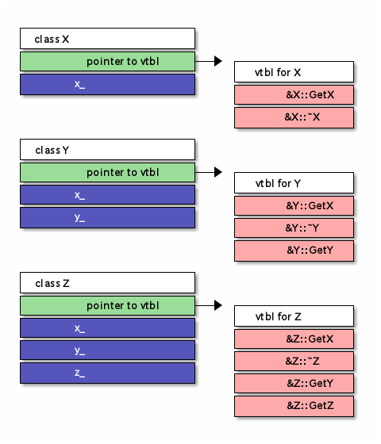

各クラスがvtblへのポインタを保持するため、このドキュメントで使用しているg++では、 sizeof(X)は8ではなく16、sizeof(Y)は16ではなく24、sizeof(Z)は24ではなく32となる。

g++の場合、以下のオプションを使用し、クラスのメモリレイアウトをファイルに出力することができる。

```cpp
    //  example/term_explanation/Makefile 29

    CCFLAGS_ADD:=-fdump-lang-class
```

X、Y、Zのメモリレイアウトは以下の様に出力される。

```
    Vtable for X
    X::_ZTV1X: 5 entries
    0     (int (*)(...))0
    8     (int (*)(...))(& _ZTI1X)
    16    (int (*)(...))X::GetX
    24    (int (*)(...))X::~X
    32    (int (*)(...))X::~X

    Class X
       size=16 align=8
       base size=16 base align=8
    X (0x0x7f54bbc23a80) 0
        vptr=((& X::_ZTV1X) + 16)

    Vtable for Y
    Y::_ZTV1Y: 6 entries
    0     (int (*)(...))0
    8     (int (*)(...))(& _ZTI1Y)
    16    (int (*)(...))Y::GetX
    24    (int (*)(...))Y::~Y
    32    (int (*)(...))Y::~Y
    40    (int (*)(...))Y::GetY

    Class Y
       size=24 align=8
       base size=24 base align=8
    Y (0x0x7f54bbc3f000) 0
        vptr=((& Y::_ZTV1Y) + 16)
      X (0x0x7f54bbc23d20) 0
          primary-for Y (0x0x7f54bbc3f000)

    Vtable for Z
    Z::_ZTV1Z: 7 entries
    0     (int (*)(...))0
    8     (int (*)(...))(& _ZTI1Z)
    16    (int (*)(...))Z::GetX
    24    (int (*)(...))Z::~Z
    32    (int (*)(...))Z::~Z
    40    (int (*)(...))Z::GetY
    48    (int (*)(...))Z::GetZ

    Class Z
       size=32 align=8
       base size=32 base align=8
    Z (0x0x7f54bbc3f068) 0
        vptr=((& Z::_ZTV1Z) + 16)
      Y (0x0x7f54bbc3f0d0) 0
          primary-for Z (0x0x7f54bbc3f068)
        X (0x0x7f54bbc43060) 0
            primary-for Y (0x0x7f54bbc3f0d0)
```

このようなメモリレイアウトは、

```cpp
    //  example/term_explanation/class_layout_ut.cpp 40

    auto z_ptr = new Z;
```

のようなオブジェクト生成に密接に関係する。その手順を下記の疑似コードにより示す。

```cpp
    // ステップ1  メモリアロケーション
    void* ptr = malloc(sizeof(Z));

    // ステップ2  ZオブジェクトのX部分の初期化
    X* x_ptr = (X*)ptr;
    x_ptr->vtbl = &vtbl_for_X       // Xのコンストラクタ呼び出し処理
    x_ptr->x_ = 1;                  // Xのコンストラクタ呼び出し処理

    // ステップ3  ZオブジェクトのY部分の初期化
    Y* y_ptr = (Y*)ptr;
    y_ptr->vtbl = &vtbl_for_Y       // Yのコンストラクタ呼び出し処理
    y_ptr->y_ = 2;                  // Yのコンストラクタ呼び出し処理

    // ステップ4  ZオブジェクトのZ部分の初期化
    Z* z_ptr = (Z*)ptr;
    z_ptr->vtbl = &vtbl_for_Z       // Zのコンストラクタ呼び出し処理
    z_ptr->z_ = 3;                  // Zのコンストラクタ呼び出し処理
```

オブジェクトの生成がこのように行われるため、Xのコンストラクタ内で仮想関数GetX()を呼び出した場合、 その時のvtblへのポインタはXのvtblを指しており(上記ステップ2)、X::GetX()の呼び出しとなる (Z::GetX()の呼び出しとはならない)。

なお、オブジェクトの解放は生成とは逆の順番で行われる。

### オーバーライドとオーバーロードの違い

下記例では、Base::g()がオーバーロードで、Derived::f()がオーバーライドである (Derived::g()はオーバーロードでもオーバーライドでもない(「name-hiding」参照))。

```cpp
    //  example/term_explanation/override_overload_ut.cpp 5

    class Base {
    public:
        virtual ~Base() = default;
        virtual std::string f() { return "Base::f"; }
        std::string         g() { return "Base::g"; }

        // g()のオーバーロード
        std::string g(int) { return "Base::g(int)"; }
    };

    class Derived : public Base {
    public:
        // Base::fのオーバーライド
        virtual std::string f() override { return "Derived::f"; }

        // Base::gのname-hiding
        std::string g() { return "Derived::g"; }
    };
```

下記図の通り、

- BaseのインスタンスはBase用のvtblへのポインタを内部に持ち、 そのvtblでBase::f()のアドレスを保持する。
- DerivedのインスタンスはDerived用のvtblへのポインタを内部に持ち、 そのvtblでDerived::f()のアドレスを保持する。
- Base::g()、Base::g(int)、 Derived::g()のアドレスはBaseやDerivedのインスタンスから辿ることはできない。

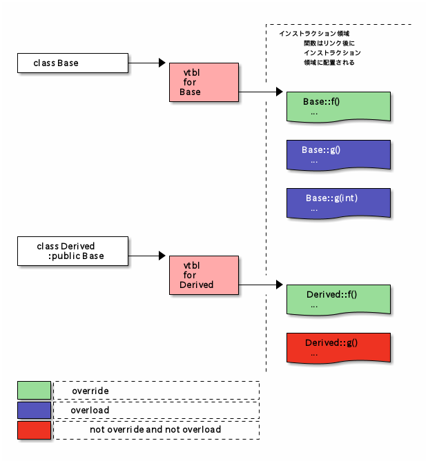

vtblとは仮想関数テーブルとも呼ばれる、仮想関数ポインタを保持するための上記のようなテーブルである (「ポリモーフィックなクラス」参照)。

Base::f()、Derived::f()の呼び出し選択は、オブジェクトの表層の型ではなく、実際の型により決定される。 Base::g()、Derived::g()の呼び出し選択は、オブジェクトの表層の型により決定される。

```cpp
    //  example/term_explanation/override_overload_ut.cpp 29

    auto  ret   = std::string{};
    auto  b     = Base{};
    auto  d     = Derived{};
    Base& d_ref = d;

    ret = b.f();  // Base::f()呼び出し
    ASSERT_EQ("Base::f", ret);

    ret = d.f();  // Derived::f()呼び出し
    ASSERT_EQ("Derived::f", ret);

    ret = b.g();  // Base::g()呼び出し
    ASSERT_EQ("Base::g", ret);

    ret = d.g();  // Derived::g()呼び出し
    ASSERT_EQ("Derived::g", ret);
    // ret = d.g(int{});   // Derived::gによって、Base::gが隠されるのでコンパイルエラー

    ret = d_ref.f();  // Base::fはDerived::fによってオーバーライドされたので、Derived::f()呼び出し
    ASSERT_EQ("Derived::f", ret);

    ret = d_ref.g();  // d_refの表層型はBaseなので、Base::g()呼び出し
    ASSERT_EQ("Base::g", ret);

    ret = d_ref.g(int{});  // d_refの表層型はBaseなので、Base::g(int)呼び出し
    ASSERT_EQ("Base::g(int)", ret);
```

上記のメンバ関数呼び出し

```cpp
    d_ref.f()
```

がどのように解釈され、Derived::f()が選択されるかを以下に疑似コードで例示する。

```cpp
    vtbl = d_ref.vtbl             // d_refの実態はDerivedなのでvtblはDerivedのvtbl

    member_func = vtbl->f         // vtbl->fはDerived::f()のアドレス

    (d_ref.*member_func)(&d_ref)  // member_func()の呼び出し
```

このようなメカニズムにより仮想関数呼び出しが行われる。

### RTTI

RTTI(Run-time Type Information)とは、プログラム実行中のオブジェクトの型を導出するための機能であり、 具体的には下記の3つの要素を指す。

- dynamic_cast
- typeid
- std::type_info

#### dynamic_cast

dynamic_castは、実行時の型チェックと安全なダウンキャストを行うためのキャスト演算子であるため、 ポリモーフィックなクラスとは密接な関係を持つ。

下記のようなポリモーフィックなクラスに対しては、

```cpp
    //  example/term_explanation/rtti_ut.cpp 8

    class Polymorphic_Base {  // ポリモーフィックな基底クラス
    public:
        virtual ~Polymorphic_Base() = default;
    };

    class Polymorphic_Derived : public Polymorphic_Base {  // ポリモーフィックな派生クラス
    };
```

dynamic_castは下記のように振舞う。

```cpp
    //  example/term_explanation/rtti_ut.cpp 25

    auto b = Polymorphic_Base{};
    auto d = Polymorphic_Derived{};

    Polymorphic_Base& b_ref_d = d;
    Polymorphic_Base& b_ref_b = b;

    // ポインタへのdynamic_cast
    auto* d_ptr = dynamic_cast<Polymorphic_Derived*>(&b_ref_d);
    ASSERT_EQ(d_ptr, &d);

    auto* d_ptr2 = dynamic_cast<Polymorphic_Derived*>(&b_ref_b);
    ASSERT_EQ(d_ptr2, nullptr);  // キャストできない場合、nullptrが返る

    // リファレンスへのdynamic_cast
    auto& d_ref = dynamic_cast<Polymorphic_Derived&>(b_ref_d);
    ASSERT_EQ(&d_ref, &d);

    // キャストできない場合、エクセプションのが発生する
    ASSERT_THROW(dynamic_cast<Polymorphic_Derived&>(b_ref_b), std::bad_cast);
```

一方で、下記のような非ポリモーフィックなクラスに対しては、

```cpp
    //  example/term_explanation/rtti_ut.cpp 102

    class NonPolymorphic_Base {  // 非ポリモーフィックな基底クラス
    };

    class NonPolymorphic_Derived : public NonPolymorphic_Base {  // 非ポリモーフィックな派生クラス
    };
```

dynamic_castは下記のように振舞う。

```cpp
    //  example/term_explanation/rtti_ut.cpp 115

    auto b = NonPolymorphic_Base{};
    auto d = NonPolymorphic_Derived{};

    NonPolymorphic_Base& b_ref_d = d;
    NonPolymorphic_Base& b_ref_b = b;

    #if 0  // 非ポリモーフィックなクラスへのdynamic_castはill-formedになる
    auto* d_ptr = dynamic_cast<NonPolymorphic_Derived*>(&b_ref_d);
    auto* d_ptr2 = dynamic_cast<NonPolymorphic_Derived*>(&b_ref_b);

    //virtual関数を持たないため、リファレンスへのdynamic_castはコンパイルできない
    auto& d_ref = dynamic_cast<NonPolymorphic_Derived&>(b_ref_d);
    ASSERT_THROW(dynamic_cast<NonPolymorphic_Derived&>(b_ref_b), std::bad_cast);
    #endif
```

#### typeid

typeidはRTTIオブジェクトの型情報 (std::type_info)を実行時に取得するための演算子である。 dynamic_castとは違い、 typeidのオペランドはポリモーフィックなクラスのインスタンスでなくても良い。 以下の例では基本型に対するtypeidが返すstd::type_infoの振る舞いを表す。

```cpp
    //  example/term_explanation/rtti_ut.cpp 52

    int   i{};
    long  j{};
    auto& i_ref = i;

    auto const& type_info_i     = typeid(i);
    auto const& type_info_i_ref = typeid(i_ref);

    ASSERT_NE(typeid(i), typeid(j));
    ASSERT_EQ(type_info_i, type_info_i_ref);
    ASSERT_STREQ(type_info_i.name(), "i");  // 実装定義の型名(clang++/g++ではintはi)
```

下記のようなポリモーフィックなクラスのインスタンスに関して、

```cpp
    //  example/term_explanation/rtti_ut.cpp 8

class Polymorphic_Base {  // ポリモーフィックな基底クラス
public:
    virtual ~Polymorphic_Base() = default;
};

class Polymorphic_Derived : public Polymorphic_Base {  // ポリモーフィックな派生クラス
};
```

typeidが返すstd::type_infoオブジェクトは下記のように振舞う。

```cpp
    //  example/term_explanation/rtti_ut.cpp 65

    auto b = Polymorphic_Base{};
    auto d = Polymorphic_Derived{};

    Polymorphic_Base& b_ref_d = d;
    Polymorphic_Base& b_ref_b = b;

    // ポリモーフィックなクラスインスタンスに対するtypeidが返す
    // std::type_infoオブジェクトが示す型は、オペランドの実際の型である。
    // * b_ref_dの表層の型:Polymorphic_Base
    // * b_ref_dの実際の型:Polymorphic_Derived
    // 下記のアサーションはこのことを表す。
    ASSERT_EQ(typeid(b_ref_d), typeid(d));  // b_ref_dとdの実際の型が同じであることを示す
    ASSERT_EQ(typeid(b_ref_b), typeid(b));  // b_ref_bとbの表層の型が同じであることを示す
```

一方で、下記のような非ポリモーフィックなクラスに対しては、

```cpp
    //  example/term_explanation/rtti_ut.cpp 102

    class NonPolymorphic_Base {  // 非ポリモーフィックな基底クラス
    };

    class NonPolymorphic_Derived : public NonPolymorphic_Base {  // 非ポリモーフィックな派生クラス
    };
```

typeidが返すstd::type_infoオブジェクトは下記のように振舞う。

```cpp
    //  example/term_explanation/rtti_ut.cpp 139

    auto b = NonPolymorphic_Base{};
    auto d = NonPolymorphic_Derived{};

    NonPolymorphic_Base& b_ref_d = d;
    NonPolymorphic_Base& b_ref_b = b;

    // 非ポリモーフィックなクラスインスタンスに対するtypeidが返す
    // std::type_infoオブジェクトが示す型は、オペランドの表層の型である。
    // * b_ref_dの表層の型:Polymorphic_Base
    // * b_ref_dの実際の型:Polymorphic_Derived
    // 下記のアサーションはこのことを表す。
    ASSERT_EQ(typeid(b_ref_d), typeid(b));  // b_ref_dとdの表層の型が同じであることを示す
    ASSERT_EQ(typeid(b_ref_b), typeid(b));  // b_ref_bとbの表層の型が同じであることを示す
```

従って、このような場合のtypeidは静的な型(表層の型)に対しての情報を返すため、 コンパイル時にのみ評価され、ランタイム時に評価されない。

ポリモーフィックなクラスのオブジェクトをオペランドとするtypeidの実行は、 そのオペランドの実際のオブジェクトの型を取得することはすでに示した。 このような場合、オペランド式は実行時に評価される。以下のコードはそのことを表している。

```cpp
    //  example/term_explanation/rtti_ut.cpp 87

    Polymorphic_Base    base;
    Polymorphic_Derived derived;
    Polymorphic_Base*   base_ptr = &derived;

    ASSERT_EQ(typeid(Polymorphic_Derived), typeid(*base_ptr));
    ASSERT_EQ(typeid(Polymorphic_Base), typeid(*(base_ptr = &base)));  // 注意

    // ポリモーフィックなクラスは対しては、typeid内の式が実行される
    ASSERT_EQ(base_ptr, &base);  // base_ptr = &baseが実行される
```

一方、非ポリモーフィックなクラスのオブジェクトをオペランドとするtypeidのオペランド式は、 コンパイル時に処理されるため、その式は実行されない。以下のコードはそのことを表している。

```cpp
    //  example/term_explanation/rtti_ut.cpp 161

    NonPolymorphic_Base    base;
    NonPolymorphic_Derived derived;
    NonPolymorphic_Base*   base_ptr = &derived;

    ASSERT_NE(typeid(NonPolymorphic_Derived), typeid(*base_ptr));
    ASSERT_EQ(typeid(NonPolymorphic_Base), typeid(*(base_ptr = &base)));  // 注意

    // 非ポリモーフィックなクラスに対しては、typeid内の式は実行されない
    ASSERT_EQ(base_ptr, &derived);  // base_ptr = &baseは実行されない
```

#### std::type_info

type_infoクラスは、typeid演算子によって返される、型の情報が格納された型である。

std::type_infoはコンパイラの実装で定義された型名を含んでいる。 以下のコードで示したように`std::type_info::name()`によりその型名を取り出すことができる。

```cpp
    //  example/term_explanation/rtti_ut.cpp 179

    auto s = std::string{"str"};
    auto v = std::string_view{"str"};
    auto b = std::byte{0b1001};

    ASSERT_STREQ(typeid(s).name(), "Ss");       // 実装定義の型名
    ASSERT_STREQ(typeid(b).name(), "St4byte");  // 実装定義の型名
    ASSERT_STREQ(typeid(v).name(), "St17basic_string_viewIcSt11char_traitsIcEE");
```

`std::type_info::name()`が返すCスタイルの文字列リテラルを、 「人間が認知できる元の型名に戻す関数」を通常のコンパイラは独自に提供する。 このドキュメントのコードのコンパイルに使用しているg++/clang++では、 そのような関数は、`abi::__cxa_demangle`である。

`std::type_info::name()`と`abi::__cxa_demangle`を利用して、 オブジェクトの被修飾型名をstd::stringオブジェクトとして取り出す関数とその使用例を以下に示す。

```cpp
    //  example/term_explanation/rtti_ut.cpp 191

    #include <cxxabi.h>  // g++/clang++実装依存ヘッダ abi::__cxa_demangleの宣言

    #include <memory>
    #include <string>

    template <typename T>
    std::string type2str(T&& obj)
    {
        int status;

        // objに基づく型情報を取得
        auto demangled = std::unique_ptr<char, decltype(&std::free)>{abi::__cxa_demangle(typeid(obj).name(), 0, 0, &status),
                                                                     &std::free};

        return demangled ? demangled.get() : "unknown";
    }
```

```cpp
    //  example/term_explanation/rtti_ut.cpp 213

    int   i{};
    auto  s     = std::string{"str"};
    auto& s_ref = s;
    auto  v     = std::string_view{"str"};

    ASSERT_EQ(type2str(i), "int");
    ASSERT_EQ(type2str(s), "std::string");
    ASSERT_EQ(type2str(s_ref), "std::string");
    ASSERT_EQ(type2str(v), "std::basic_string_view<char, std::char_traits<char> >");

    auto b = Polymorphic_Base{};
    auto d = Polymorphic_Derived{};

    Polymorphic_Base& b_ref_d = d;
    Polymorphic_Base& b_ref_b = b;

    ASSERT_EQ(type2str(b_ref_d), "Polymorphic_Derived");  // b_ref_dの実際の型はPolymorphic_Derived
    ASSERT_EQ(type2str(b_ref_b), "Polymorphic_Base");     // b_ref_bの実際の型はPolymorphic_Base
```